# Plotting tools

Silvia Castiglione, Carmela Serio, Pasquale Raia

## Index

1. plotting RRphylo outputs onto the tree
2. plotting RRphylo rates
3. plotting search.trend results
4. plotting search.shift results
5. plotting search.conv results

## plotting RRphylo outputs onto the tree

Phenotypic and evolutionary rate values can be plotted onto the tree branches by means of `plotRR`. The function takes as mandatory objects the result of `RRphylo`, the vector/matrix of phenotypic values (`y`) used to generate the `RR` object, and a `multivariate` argument indicating whether individual rates for each variable (`"multiple.rates"`) or the norm2 vector of multivariate rates (`"rates"`) should be plotted. The output includes two customized functions to chart phenotypic values/evolutionary rates along the tree branches: `plotRRphen` and `plotRRrates`. The plots generated by both these functions are completely customizable by providing a list of `tree.args`, being all the arguments usually passed to the function `plot.phylo`, a `color.pal` function to generate the color palette and a list of `colorbar.args` to be passed to the function `colorbar`. The only mandatory argument for `plotRRphen` and `plotRRrates` with multivariate data is the name or the number of the `variable` to plot.

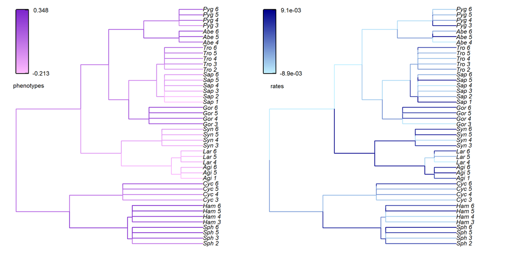

```r
### load the RRphylo example dataset including Apes tree and shape data (multivariate)
data("DataApes")
DataApes$PCstage->PCstage
DataApes$Tstage->Tstage

# Perform RRphylo
RRphylo(tree=Tstage,y=PCstage)->RR

# Visualize phenotypic values and "multiple" evolutionary rates onto the
# phylogenetic tree.
plotRR(RR,y=PCstage,multivariate="multiple.rates")->pRRmulti

# Visualize phenotypic values and the norm2 vector of multiple rates onto the
# phylogenetic tree.
plotRR(RR,y=PCstage,multivariate="rates")->pRR

# Using default options
pRRmulti$plotRRphen(variable=1,colorbar.args = list(title.pos="bottom"))
pRRmulti$plotRRrates(variable=2,colorbar.args = list(title.pos="bottom"))
```

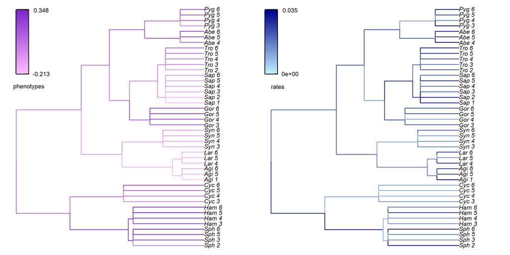

```r
# Using default options
pRR$plotRRphen(variable=1,colorbar.args = list(title.pos="bottom")) # this is the same as before of course
pRR$plotRRrates(colorbar.args = list(title.pos="bottom"))
```

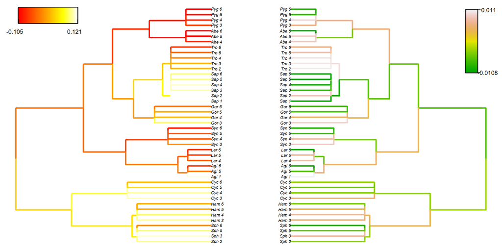

```r
# Customizing parameters
pRRmulti$plotRRphen(variable=3,tree.args=list(edge.width=2,cex=0.7),color.pal=heat.colors,
               colorbar.args = list(x="topleft",direction="h",labs.adj=0.7,xpd=TRUE,title.pos="bottom"))
pRRmulti$plotRRrates(variable=4,tree.args=list(edge.width=2,direction="leftwards",cex=0.7),
                color.pal=terrain.colors,colorbar.args = list(x="topright",labs.adj=0.7,xpd=TRUE,tck.pos="out"))
```

## plotting RRphylo rates

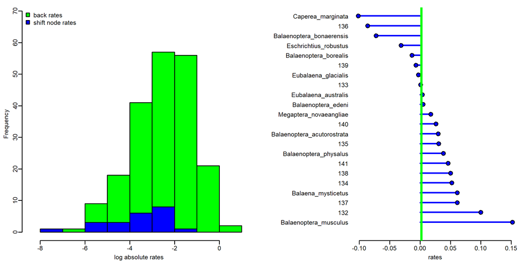

```r
### load the RRphylo example dataset including Cetaceans tree and ln body masses
data("DataCetaceans")
DataCetaceans$treecet->treecet
DataCetaceans$masscet->masscet

# Perform RRphylo
RRphylo(treecet,masscet)->RRcet

# Visualize evolutionary rates computed for the clade including extant Mysticetes
plotRates(RRcet,node=131)->pRates

# Using default options
par(mar=c(3,3,1,1),mgp=c(1.7,0.5,0))
pRates$plotHist()
par(mar=c(3,12,1,1),mgp=c(1.7,0.5,0))
pRates$plotLollipop()->pLol
```

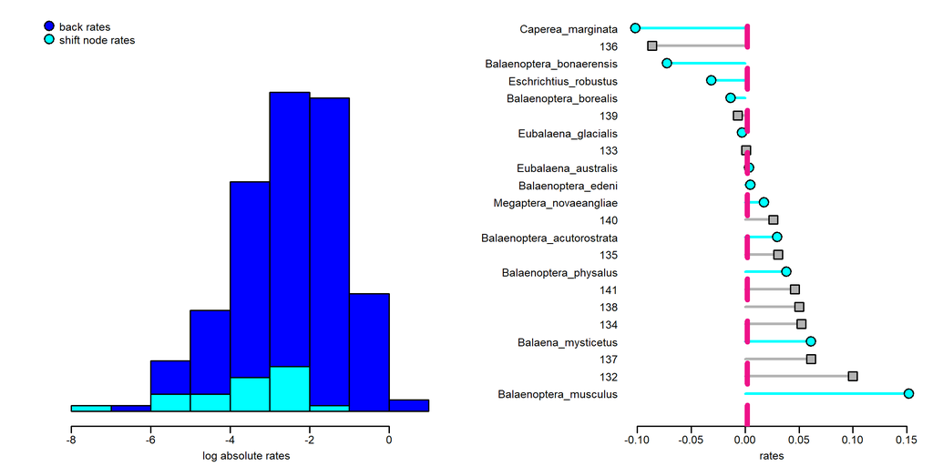

```r
# Customizing parameters
par(mar=c(3,3,1,1),mgp=c(1.7,0.5,0))
pRates$plotHist(hist.args=list(yaxt="n",ylab=NULL,col1="blue",col2="cyan"),
                legend.args = list(pch=21,pt.cex=2))

# Setting different pch and color for nodes and species
colo<-rep("gray70",length(pLol))
colo[names(pLol)%in%treecet$tip.label]<-"cyan"
pchc<-rep(22,length(pLol))
pchc[names(pLol)%in%treecet$tip.label]<-21

par(mar=c(3,12,1,1),mgp=c(1.7,0.5,0))
pRates$plotLollipop(lollipop.args = list(pch=pchc,bg=colo,col=colo,cex=2,lwd=2),
                    line.args = list(col="deeppink2",lwd=4,lty=2))->pLol2
```

## plotting search.trend results

Results for phenotypic and evolutionary rates trends through time returned by the function search.trend can be visualized by means of `plotTrend`. Such function takes as only object the output of `search.trend` and returns customized functions to produce plots of phenotypes (`plotSTphen`) and (rescaled) evolutionary rates (`plotSTrates`) versus time regressions on the entire tree. The plots generated by both these functions are basically made by a scatterplot representing the distribution of phenotypes/rates versus time, a polygon depicting the 95% CI of slopes generated according to the Brownian Motion (see search.trend for further details) and the regression line. Each of these elements can be customized by the user by specifying the arguments `plot.args`, `polygon.args`, and `line.args`. The only mandatory argument for `plotSTphen` and `plotSTrates` is the name or the number of the `variable` to plot.

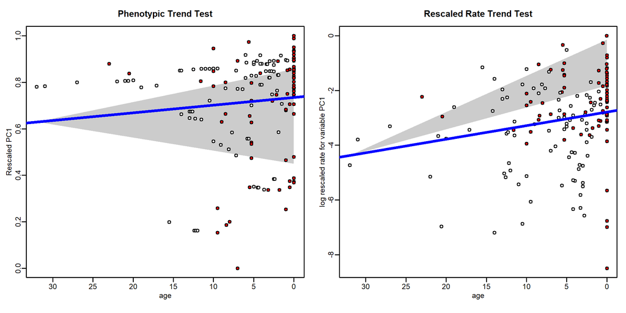

```r
### load the RRphylo example dataset including Felids tree and 4 mandible shape variables (PCs)
data("DataFelids")
DataFelids$treefel->treefel
DataFelids$PCscoresfel->PCscoresfel

# Perform RRphylo and search.trend
RRphylo(treefel,PCscoresfel)->RRfel
search.trend(RRfel,PCscoresfel)->ST

# Visualize search.trend results
plotTrend(ST)->pTrend

# Using default options
par(mfrow=c(1,2),mar=c(4,3,3,1),mgp=c(1.5,0.5,0))
pTrend$plotSTphen("PC1")
pTrend$plotSTrates(1) # This is for PC1 as well
```

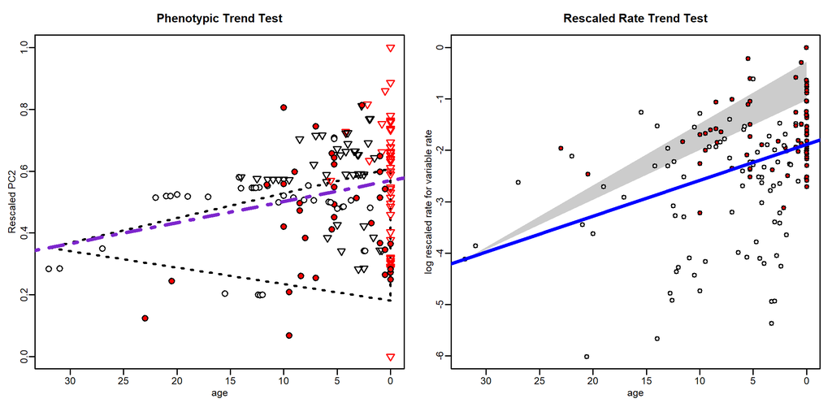

```r
## Customizing parameters
# Extracting nodes and tips descending from the most recent common ancestor of Felinae
library(phytools)
Felinae<-getDescendants(treefel,94)
Felinae[which(Felinae<=Ntip(treefel))]<-treefel$tip.label[Felinae[which(Felinae<=Ntip(treefel))]]

# Setting different pch for Felinae only
pchc<-rep(21,nrow(ST$trend.data$phenotypeVStime))
pchc[rownames(ST$trend.data$phenotypeVStime)%in%Felinae]<-6


par(mfrow=c(1,2),mar=c(4,3,3,1),mgp=c(1.5,0.5,0))
pTrend$plotSTphen("PC2",plot.args = list(pch=pchc,cex=1.3),
                polygon.args = list(col="white",border="black",lwd=2,lty=3),
                line.args = list(lty=4,col="purple3"))

# When multivariate data are used, a "rate" vector is calculated as the 2-norm
# vector of rates computed for each individual variable. The "total rate" can be plotted:
pTrend$plotSTrates("rate") # Equivalent to setting variable = 5
```

If the output of `search.trend` also includes results for phenotypic and evolutionary rates trends trough time occurring at individual clades in the tree, `plotTrend` returns two additional functions to generate plots for individual nodes (`plotSTphenNode` and `plotSTratesNode`). As above, these functions allow the user to customize the plot by setting the parameters `plot.args` (for everything pertaining the scatterplot), `lineTree.args` and `lineNode.args` (for the regression lines for the entire tree and the clade, respectively), and `node.palette` (including as many colors as the number of nodes the plot should be produced for). Mandatory arguments are the `variable` and the indices or numbers of nodes to plot (up to 9 nodes at the same time). An argument peculiar to these functions (listed in `plot.args`) is `pch.node`, which can be used to set different pch for each node.

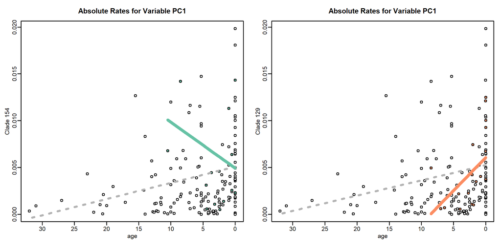

```r
# Perform search.trend setting Smilodontini and Pantherini as individual clades
cc<-2/parallel::detectCores()
search.trend(RRfel,PCscoresfel,node=c(129,154),clus=cc)->STclades

# Visualize search.trend results
plotTrend(STclades)->pTrend2
# Using default options
par(mar=c(4,3,3,1),mgp=c(1.5,0.5,0))
pTrend2$plotSTphenNode("PC1",node=1:2)
pTrend2$plotSTratesNode("PC1",node=c(154,129)) # This is the same as indicating node= 2:1
```

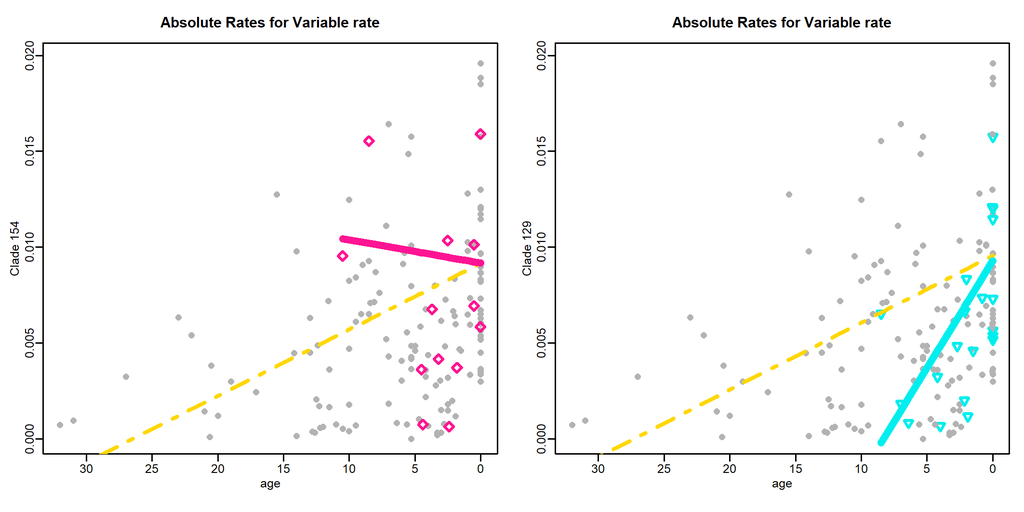

```r
## Customizing parameters
par(mar=c(4,3,3,1),mgp=c(1.5,0.5,0))
pTrend2$plotSTphenNode("PC2",node=1:2,
                    plot.args = list(pch.node=c(23,24),pch=1,col="gray70",cex=1.2),
                    lineTree.args = list(col="black",lwd=3),lineNode.args = list(lwd=5),
                    node.palette = c("orangered","chartreuse"))
pTrend2$plotSTratesNode("rate",node=c(154,129),
                    plot.args = list(pch.node=c(5,6),pch=16,col="gray70",cex=1.2,lwd=2),
                    lineTree.args = list(col="gold",lwd=3,lty=4),
                    lineNode.args = list(lwd=5),
                    node.palette = c("deeppink","cyan2"))
```

## plotting search.shift results

Evolutionary rate shifts located on the tree by the function search.shift can be visualized by means of `plotShift`. The function takes as mandatory objects the outputs of `RRphylo` and `search.shift` and returns customized functions to produce plots of evolutionary rates shifts occurring at clade level (`plotClades`) or sparse across the tree (`plotStates`), depending on the `status.type` set when performing `search.shift`. In the latter case (i.e. `status.type = "sparse"`) a further `state` argument must be provided to `plotShift`.

`plotClades` highlights the shifting clades onto the phylogenetic tree by drawing colored circles on their Most Recent Common Ancestors (MRCA). The radii of the circles are proportional to the absolute difference of the rate magnitude (see search.shift for further details), so that a circle for a clade whose mean absolute rates “shifts” more from the mean absolute rate of the tree is larger than a circle for a clade with a smaller difference. Plots for the tree and the circles can be customized by the user by specifying the arguments `tree.args` and `symbols.args`, respectively. For example, the user can choose different color options than the standard blue/red for positive/negative shifts, by setting `symbols.args=list(fg=c(pos="color for positive shift",neg="color for negative shift"))`, or provide a vector of as many colors as the number of shifting clades. The same applies to the `symbols` argument “bg”.

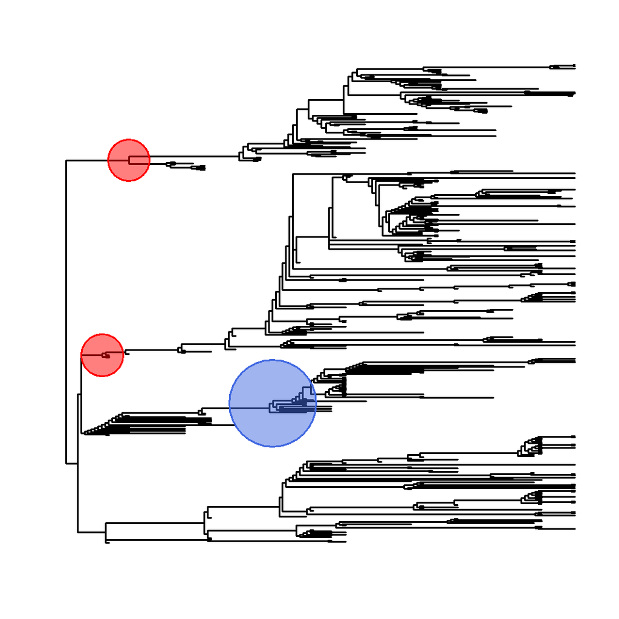

```r
### load the RRphylo example dataset including Ornithodirans tree, body mass and locomotory type
data("DataOrnithodirans")
DataOrnithodirans$treedino->treedino
DataOrnithodirans$massdino->massdino
DataOrnithodirans$statedino->statedino

# Perform RRphylo and search.shift under status.type="clade"
RRphylo(tree=treedino,y=massdino)->dinoRates
search.shift(RR=dinoRates,status.type="clade")->SSauto

# Visualize search.shift results
plotShift(RR=dinoRates,SS=SSauto)->plotSS
# Using default options
plotSS$plotClades()
```

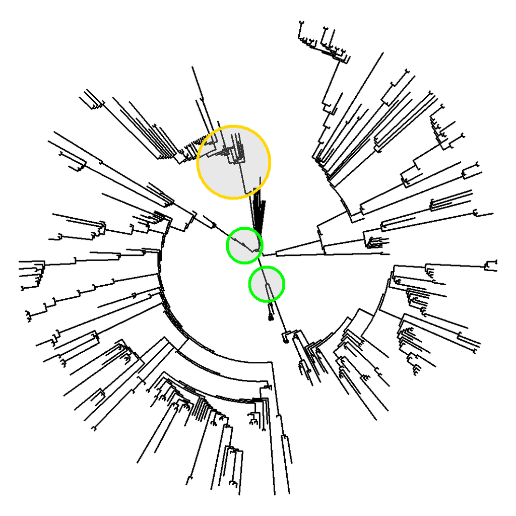

```r
## Customizing parameters
# Setting different colors for positive and negative shift
plotSS$plotClades(tree.args=list(no.margin=TRUE,type="fan"),
                  symbols.args=list(lwd=2,fg=c(pos="gold",neg="green"),
                                    bg=scales::alpha("grey70",0.3)))

# Setting different colors for each shifting clade
plotSS$plotClades(tree.args=list(no.margin=TRUE),
                  symbols.args=list(lwd=2,fg=NA,bg=scales::alpha(c("red","green","blue"),0.3)))
```

If `search.shift` was performed under `status.type = "sparse"`, the function `plotStates` (returned by `plotShift`) draws the real rate difference on the distribution of random differences generated within `search.shift` for each states. Under default settings, star shaped points represent significant results. Plots for the boxplot, the points, and the legend can be customized by the user by specifying the arguments `plot.args`, `points.args`, and `legend.args` respectively.

[figure not shown]

```r
# Perform RRphylo and search.shift under status.type="sparse"
search.shift(RR=dinoRates,status.type= "sparse",state=statedino)->SSstate

# Visualize search.shift results
plotShift(RR=dinoRates,SS=SSstate,state=statedino)->plotSS2

# Using default options
plotSS2$plotStates()
```

[figure not shown]

```r
## Customizing parameters
# Setting customized colors and pch for different states and suppressing the legend
plotSS2$plotStates(plot.args=list(pch=2,main="Dinosaur stances"),
                  points.args=list(bg=c("gold","forestgreen","royalblue","white"),
                                   col=c("black","black","black","orangered"),
                                   pch=c(21,22,24,13)),legend.args=NULL)
```

[figure not shown]

```r
# Setting customized colors and pch for different states and not suppressing the legend
plotSS2$plotStates(plot.args=list(pch=2,main="Dinosaur stances"),
                  points.args=list(bg=c("gold","forestgreen","royalblue","white"),
                                   col=c("black","black","black","orangered"),
                                   pch=c(21,22,24,13)),legend.args=list())
```